# Task 1: Treatment Effect Heterogeneity

### Dataset priority overview

| n_high | n_medium | n_low | prop_high | prop_medium_or_higher | max_priority_score | mean_priority_score | top_priority_vars | dataset_priority_hint |
| --- | --- | --- | --- | --- | --- | --- | --- | --- |
| 1 | 6 | 8 | 0.067 | 0.467 | 1.1 | 0.433 | x11, x14, x6, x5, x2 | high_plus_additional_support |

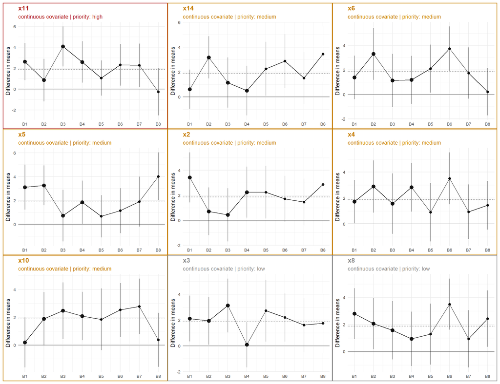

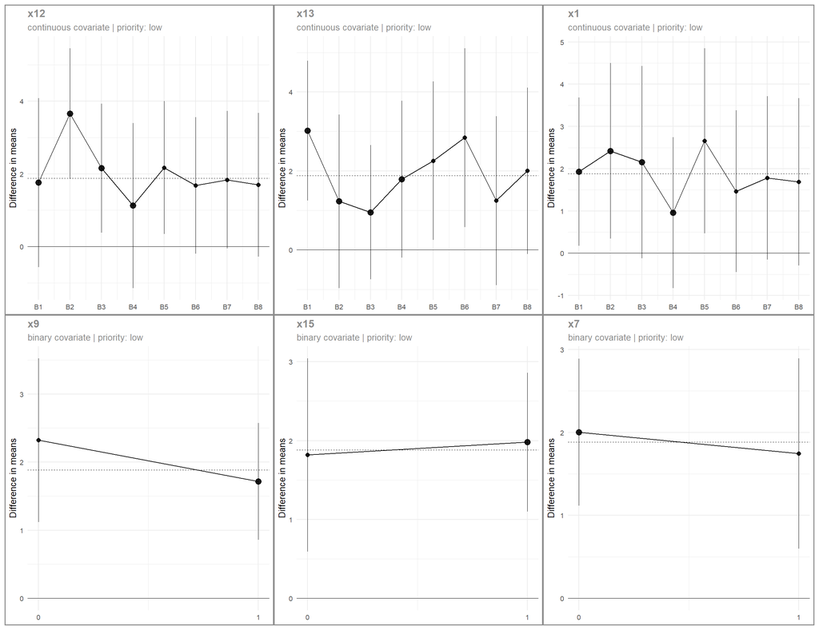

## Dataset 3972

All variables are shown. Numeric prioritisation is used only to order and colour the plots for faster visual review.

| dataset_id | endpoint | n_obs | n_vars | n_bins | overall_effect |
| --- | --- | --- | --- | --- | --- |
| 3972 | binary | 150 | 15 | 4 | 0.093 |

### Dataset priority overview

| n_high | n_medium | n_low | prop_high | prop_medium_or_higher | max_priority_score | mean_priority_score | top_priority_vars | dataset_priority_hint |
| --- | --- | --- | --- | --- | --- | --- | --- | --- |
| 6 | 4 | 5 | 0.4 | 0.667 | 1.1 | 0.608 | x13, x14, x6, x11, x2 | multiple_high_priority_signals |

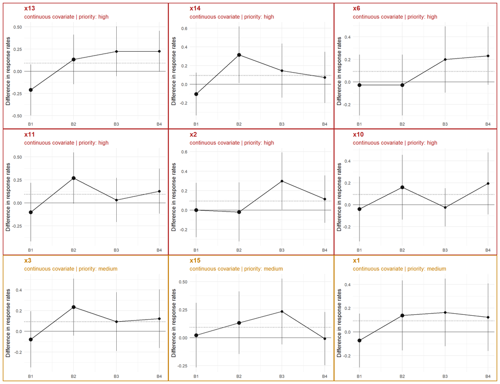

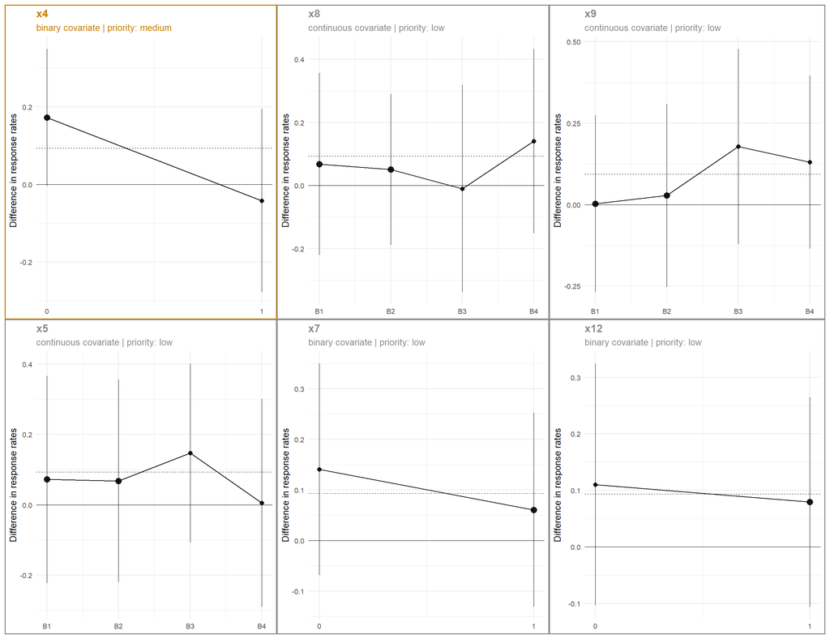

## Dataset 4017

All variables are shown. Numeric prioritisation is used only to order and colour the plots for faster visual review.

| dataset_id | endpoint | n_obs | n_vars | n_bins | overall_effect |
| --- | --- | --- | --- | --- | --- |
| 4017 | continuous | 700 | 50 | 8 | 0.596 |

### Dataset priority overview

| n_high | n_medium | n_low | prop_high | prop_medium_or_higher | max_priority_score | mean_priority_score | top_priority_vars | dataset_priority_hint |
| --- | --- | --- | --- | --- | --- | --- | --- | --- |
| 21 | 11 | 18 | 0.42 | 0.64 | 1.059 | 0.583 | x39, x19, x3, x44, x37 | multiple_high_priority_signals |

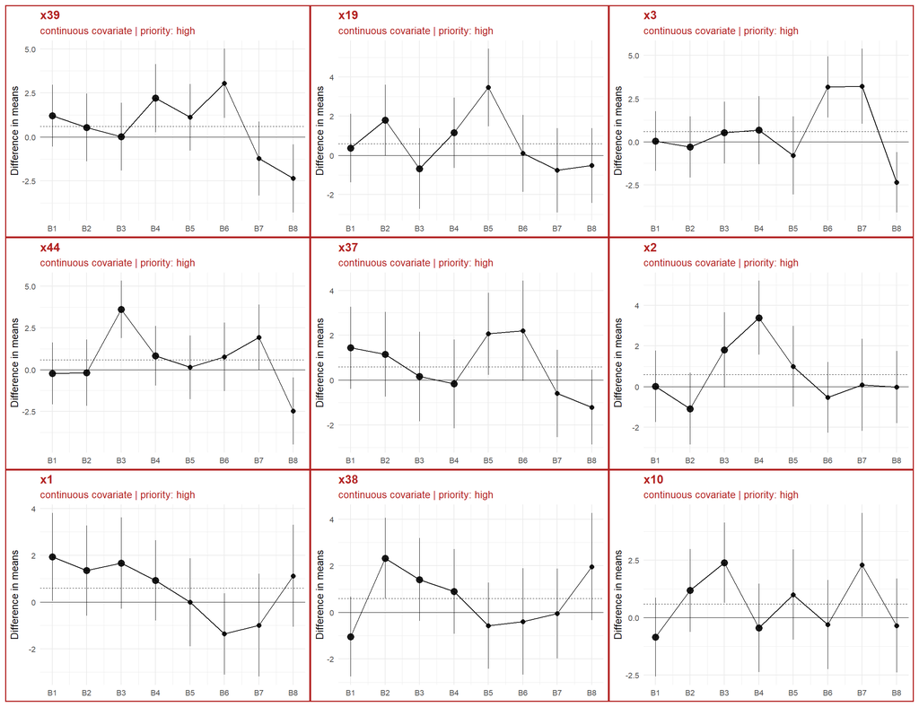

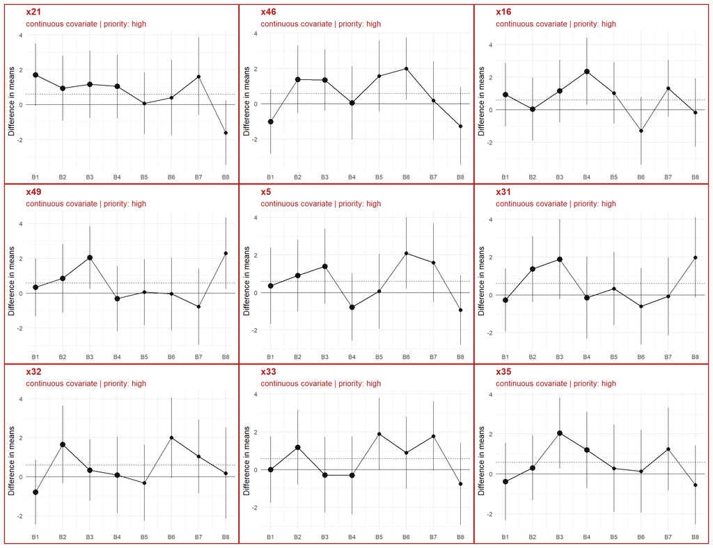

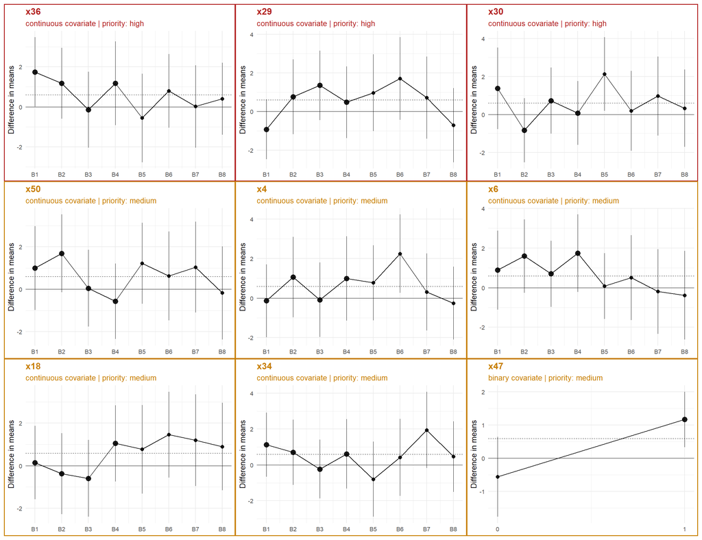

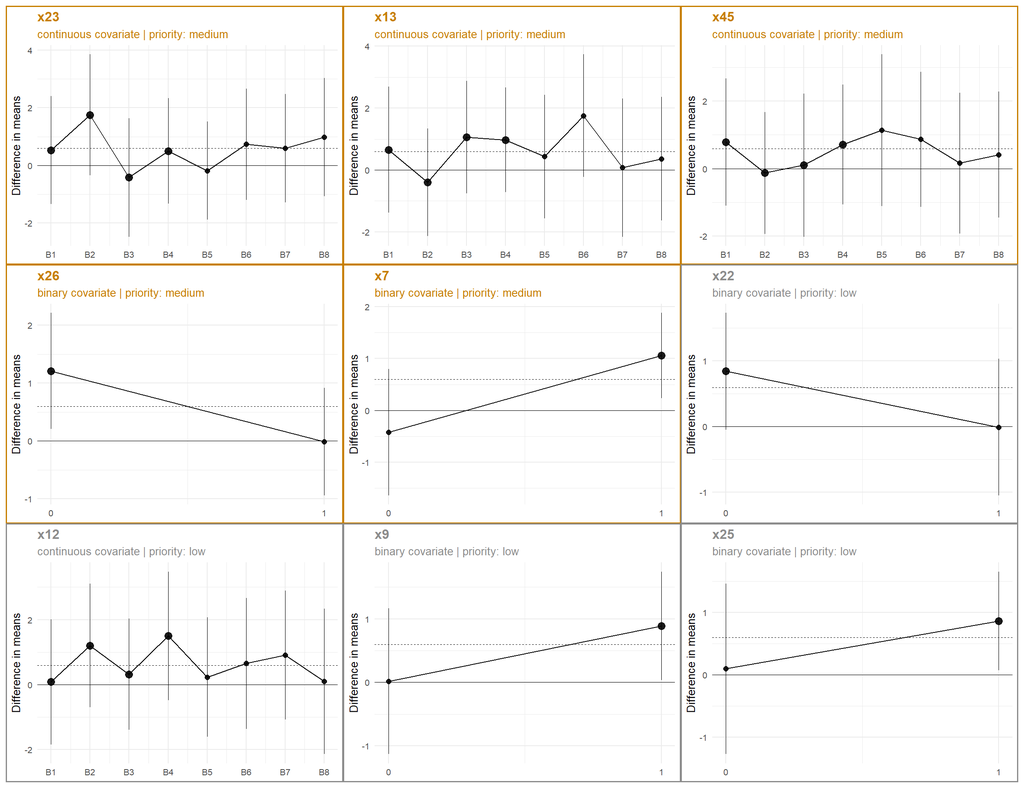

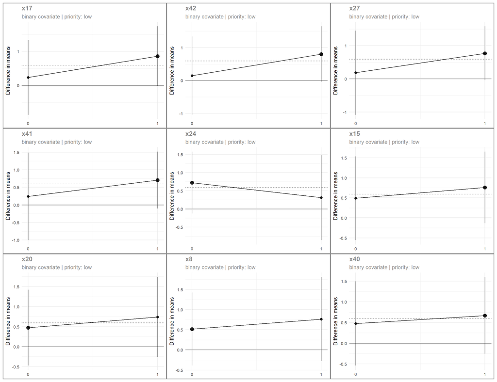

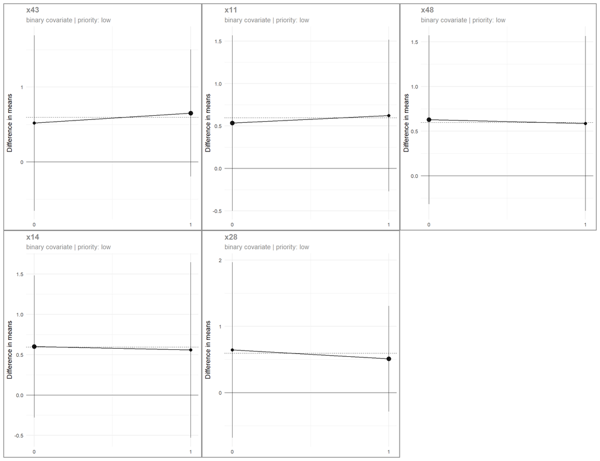

## Dataset 4368

All variables are shown. Numeric prioritisation is used only to order and colour the plots for faster visual review.

| dataset_id | endpoint | n_obs | n_vars | n_bins | overall_effect |
| --- | --- | --- | --- | --- | --- |
| 4368 | binary | 500 | 15 | 6 | -0.06 |

### Dataset priority overview

| n_high | n_medium | n_low | prop_high | prop_medium_or_higher | max_priority_score | mean_priority_score | top_priority_vars | dataset_priority_hint |
| --- | --- | --- | --- | --- | --- | --- | --- | --- |
| 6 | 6 | 3 | 0.4 | 0.8 | 0.975 | 0.617 | x8, x7, x14, x11, x3 | multiple_high_priority_signals |

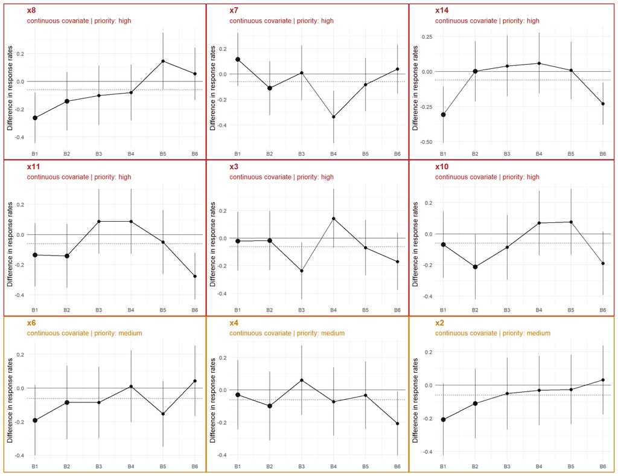

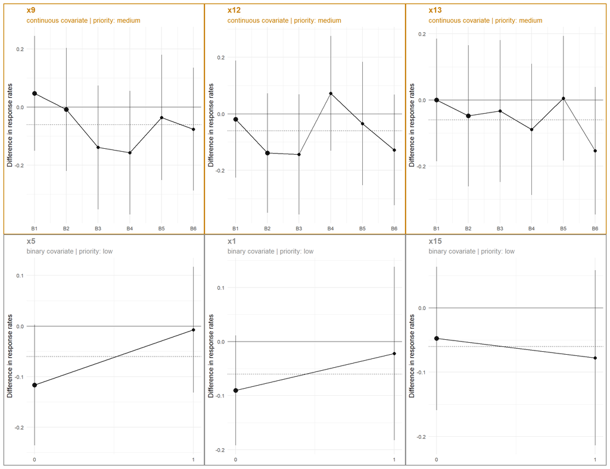

## Dataset 4380

All variables are shown. Numeric prioritisation is used only to order and colour the plots for faster visual review.

| dataset_id | endpoint | n_obs | n_vars | n_bins | overall_effect |
| --- | --- | --- | --- | --- | --- |
| 4380 | continuous | 150 | 15 | 4 | 0.675 |

### Dataset priority overview

| n_high | n_medium | n_low | prop_high | prop_medium_or_higher | max_priority_score | mean_priority_score | top_priority_vars | dataset_priority_hint |
| --- | --- | --- | --- | --- | --- | --- | --- | --- |
| 6 | 6 | 3 | 0.4 | 0.8 | 1.014 | 0.642 | x10, x5, x1, x12, x14 | multiple_high_priority_signals |

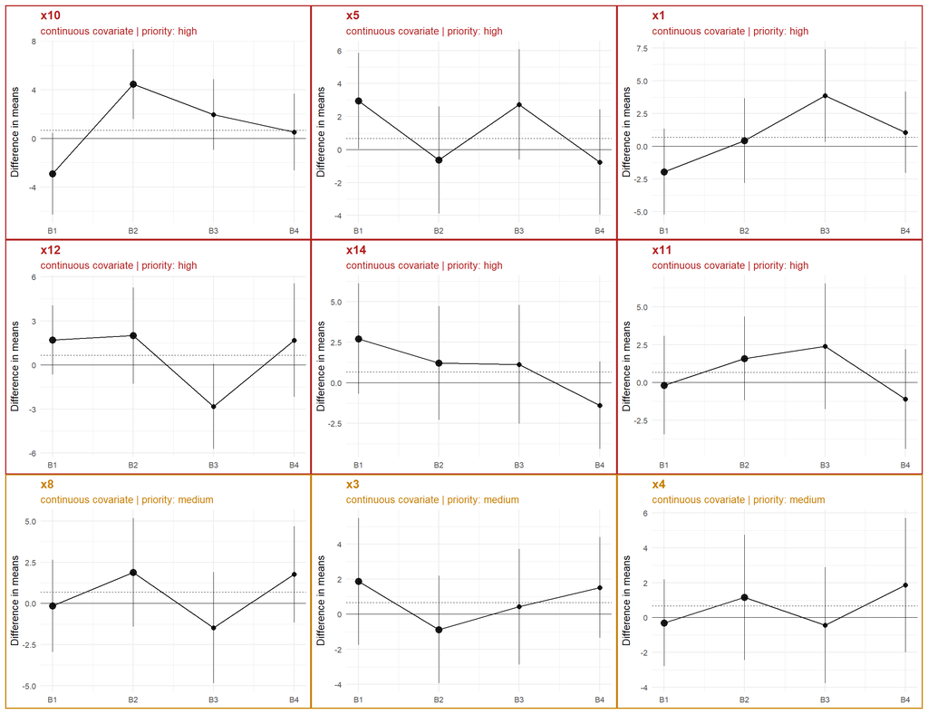

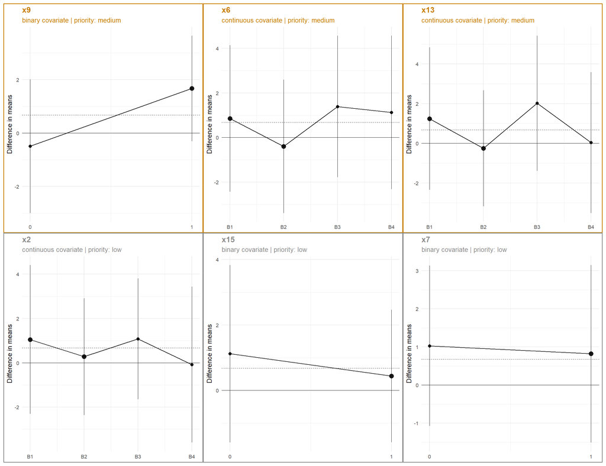

## Dataset 4502

All variables are shown. Numeric prioritisation is used only to order and colour the plots for faster visual review.

| dataset_id | endpoint | n_obs | n_vars | n_bins | overall_effect |
| --- | --- | --- | --- | --- | --- |
| 4502 | continuous | 150 | 50 | 4 | 2.048 |

### Dataset priority overview

| n_high | n_medium | n_low | prop_high | prop_medium_or_higher | max_priority_score | mean_priority_score | top_priority_vars | dataset_priority_hint |
| --- | --- | --- | --- | --- | --- | --- | --- | --- |
| 11 | 12 | 27 | 0.22 | 0.46 | 1.03 | 0.48 | x43, x33, x4, x40, x31 | multiple_high_priority_signals |

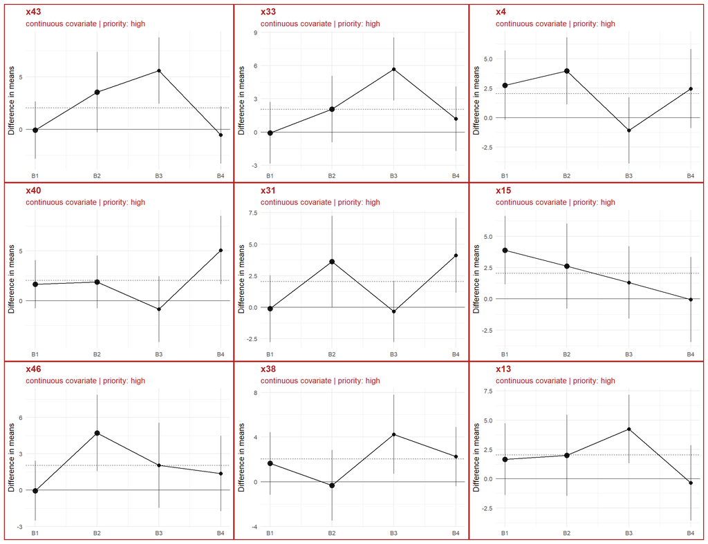

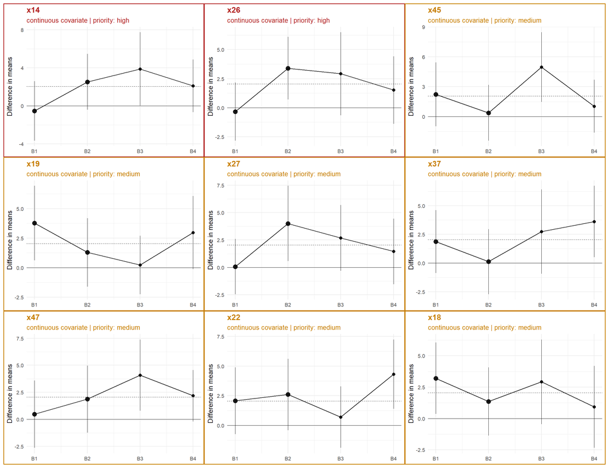

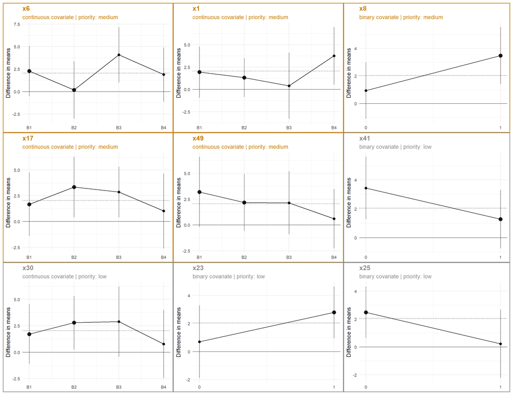

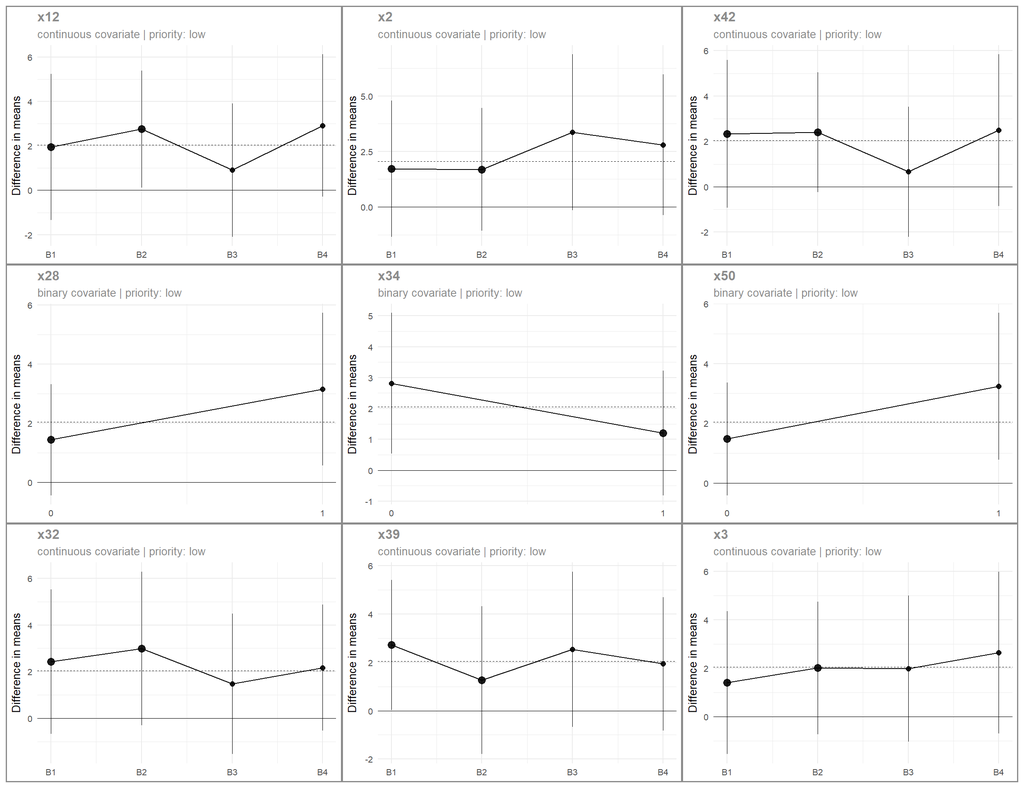

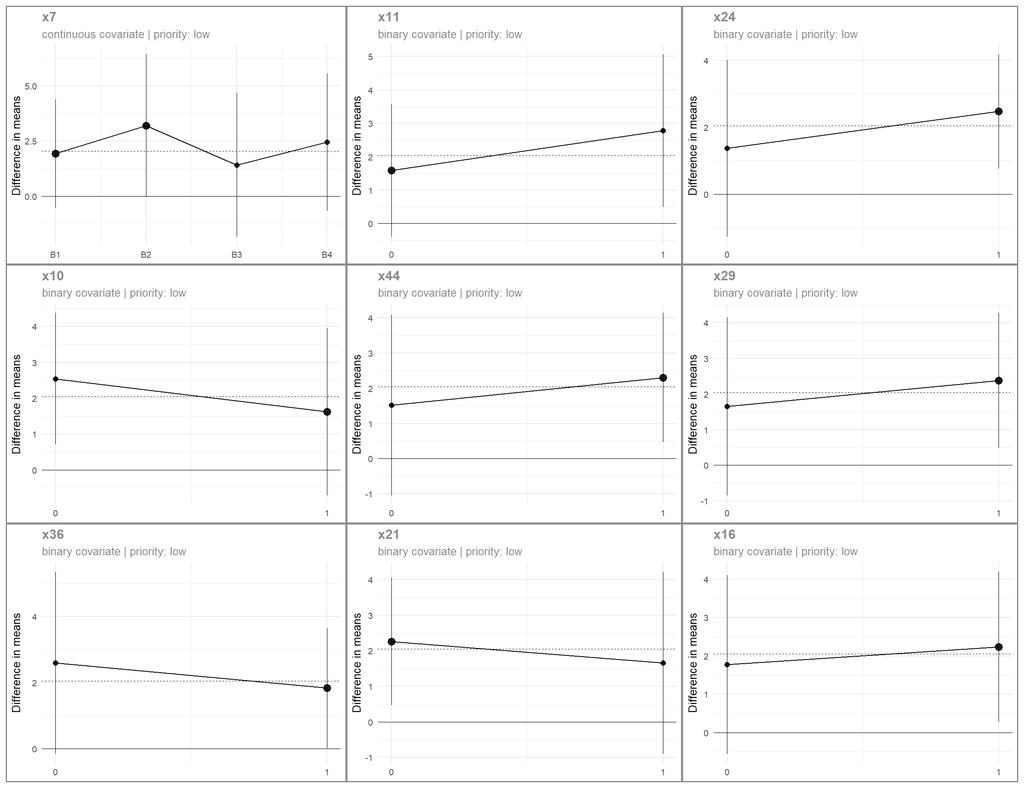

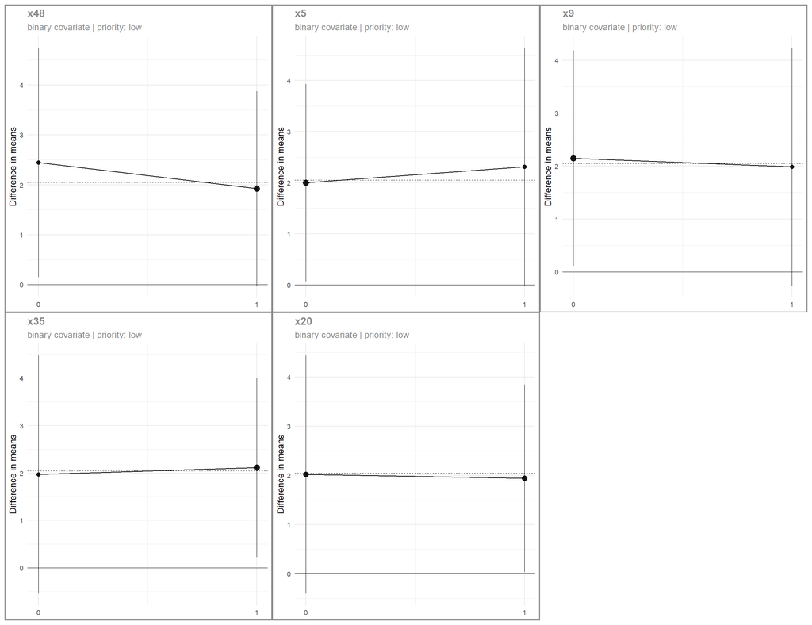

## Dataset 4913

All variables are shown. Numeric prioritisation is used only to order and colour the plots for faster visual review.

| dataset_id | endpoint | n_obs | n_vars | n_bins | overall_effect |
| --- | --- | --- | --- | --- | --- |
| 4913 | continuous | 700 | 15 | 8 | 1.028 |

### Dataset priority overview

| n_high | n_medium | n_low | prop_high | prop_medium_or_higher | max_priority_score | mean_priority_score | top_priority_vars | dataset_priority_hint |
| --- | --- | --- | --- | --- | --- | --- | --- | --- |
| 7 | 3 | 5 | 0.467 | 0.667 | 1.025 | 0.592 | x4, x6, x12, x15, x3 | multiple_high_priority_signals |

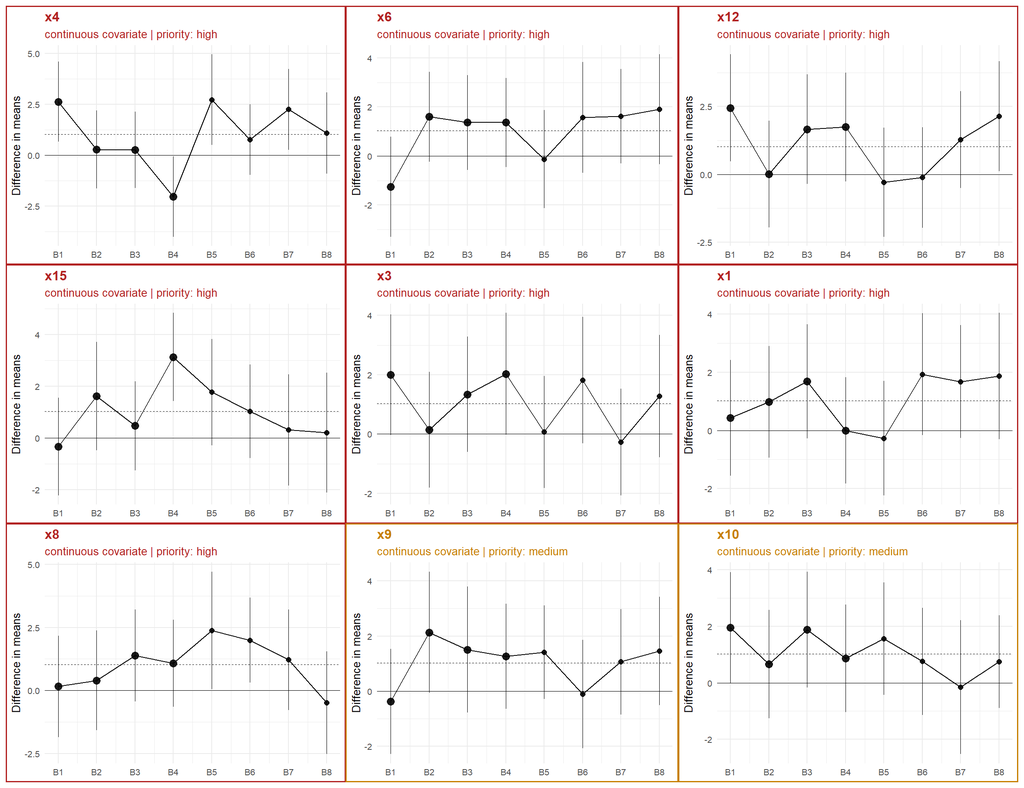

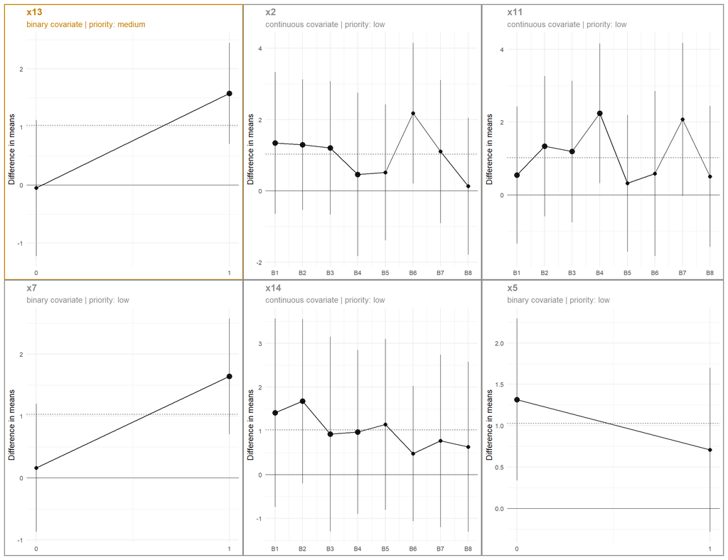

## Dataset 5053

All variables are shown. Numeric prioritisation is used only to order and colour the plots for faster visual review.

| dataset_id | endpoint | n_obs | n_vars | n_bins | overall_effect |
| --- | --- | --- | --- | --- | --- |
| 5053 | continuous | 150 | 15 | 4 | 0.142 |

### Dataset priority overview

| n_high | n_medium | n_low | prop_high | prop_medium_or_higher | max_priority_score | mean_priority_score | top_priority_vars | dataset_priority_hint |
| --- | --- | --- | --- | --- | --- | --- | --- | --- |
| 7 | 4 | 4 | 0.467 | 0.733 | 1.002 | 0.642 | x4, x9, x11, x14, x3 | multiple_high_priority_signals |

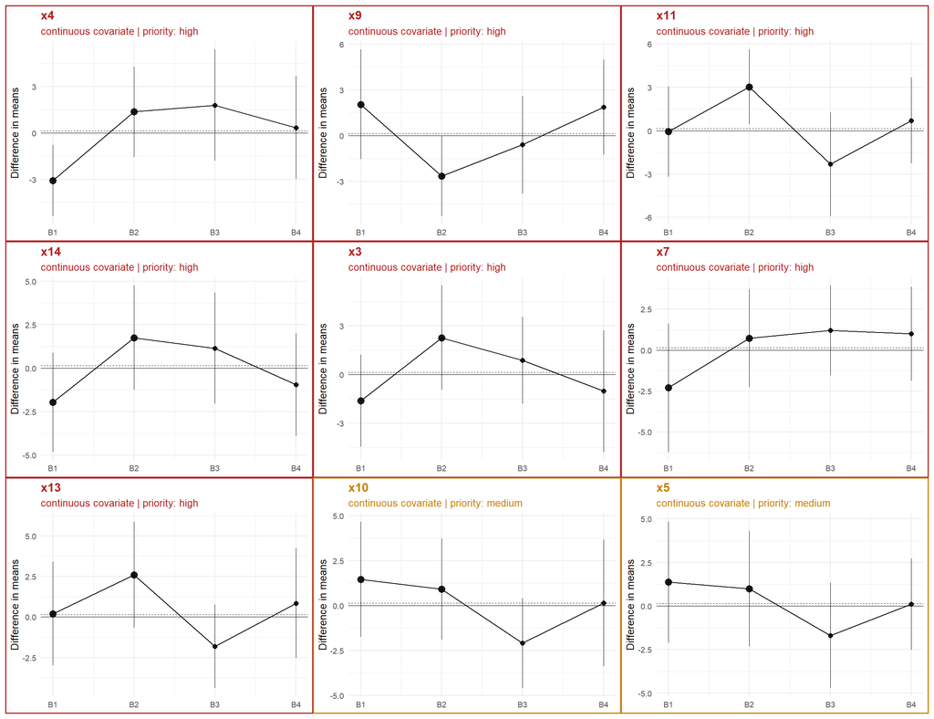

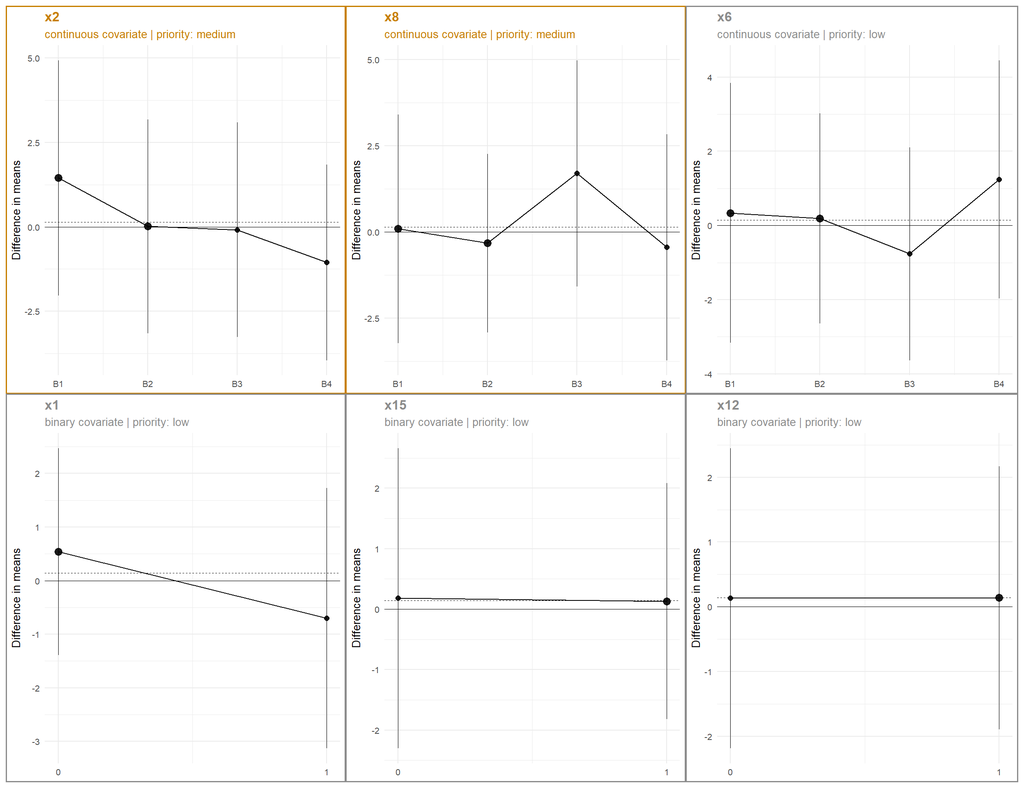

## Dataset 5492

All variables are shown. Numeric prioritisation is used only to order and colour the plots for faster visual review.

| dataset_id | endpoint | n_obs | n_vars | n_bins | overall_effect |
| --- | --- | --- | --- | --- | --- |
| 5492 | binary | 500 | 50 | 6 | 0.008 |

### Dataset priority overview

| n_high | n_medium | n_low | prop_high | prop_medium_or_higher | max_priority_score | mean_priority_score | top_priority_vars | dataset_priority_hint |
| --- | --- | --- | --- | --- | --- | --- | --- | --- |
| 22 | 16 | 12 | 0.44 | 0.76 | 1.053 | 0.655 | x10, x46, x21, x44, x50 | multiple_high_priority_signals |

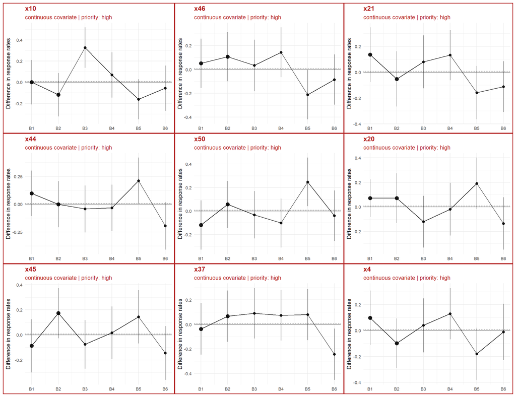

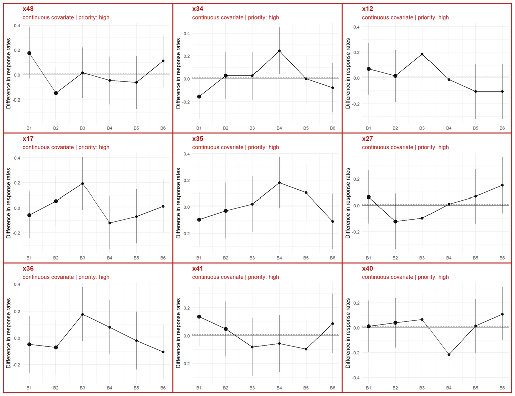

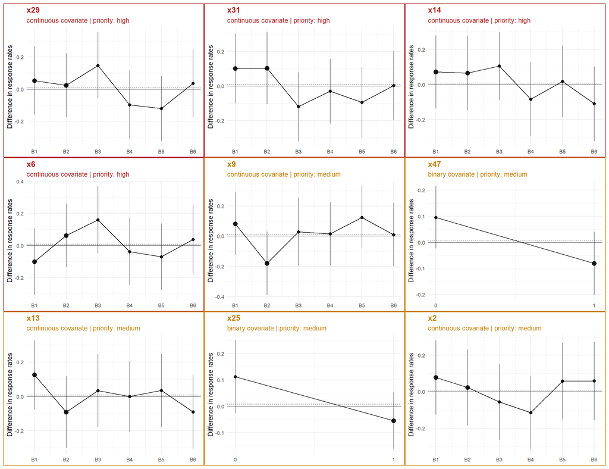

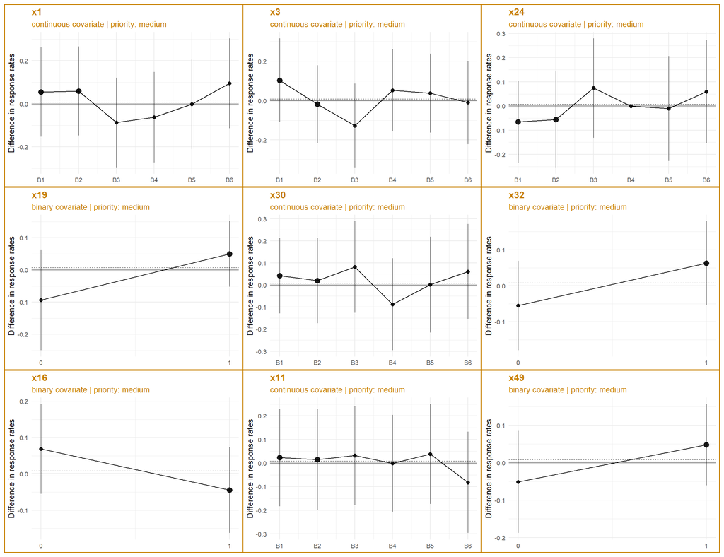

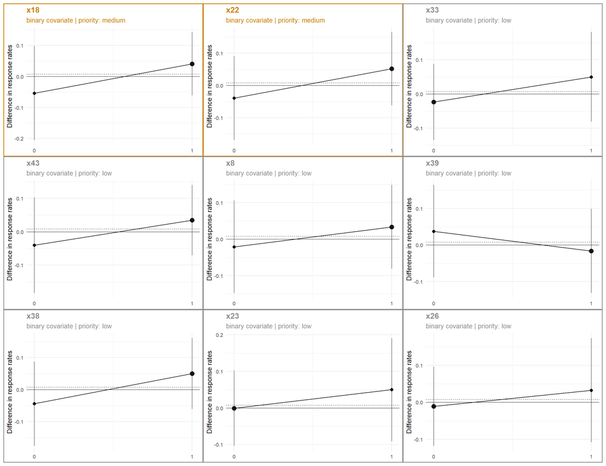

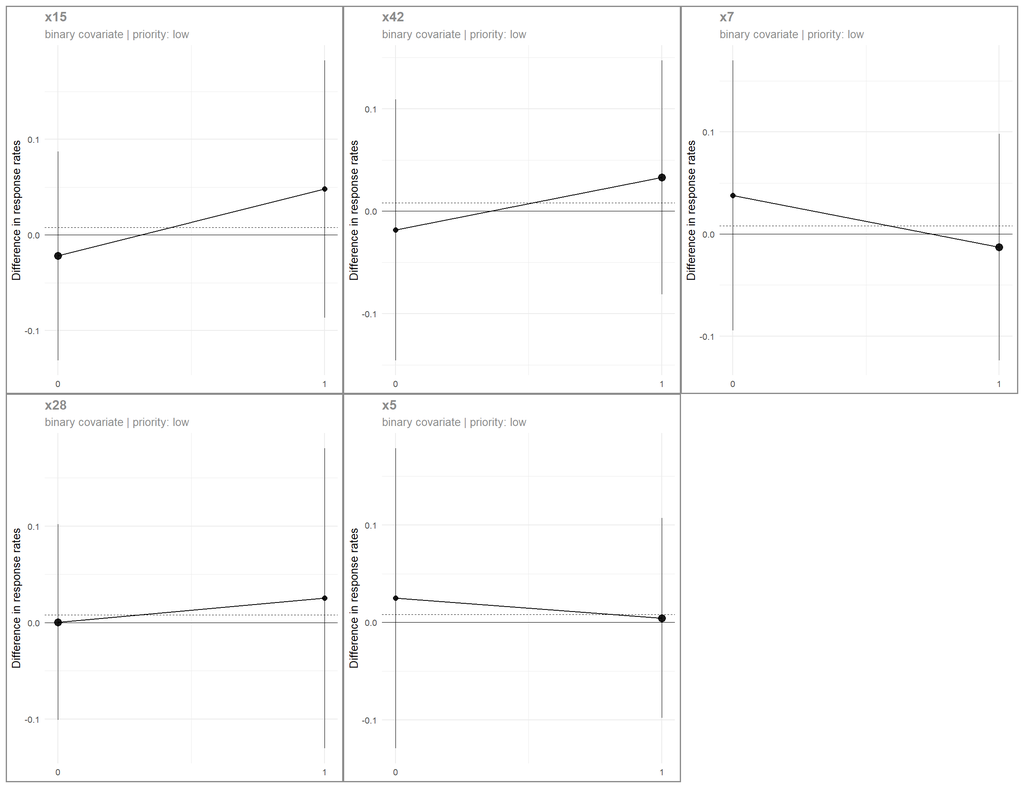

## Dataset 6025

All variables are shown. Numeric prioritisation is used only to order and colour the plots for faster visual review.

| dataset_id | endpoint | n_obs | n_vars | n_bins | overall_effect |
| --- | --- | --- | --- | --- | --- |
| 6025 | binary | 500 | 15 | 6 | 0.088 |

### Dataset priority overview

| n_high | n_medium | n_low | prop_high | prop_medium_or_higher | max_priority_score | mean_priority_score | top_priority_vars | dataset_priority_hint |
| --- | --- | --- | --- | --- | --- | --- | --- | --- |
| 5 | 3 | 7 | 0.333 | 0.533 | 0.982 | 0.525 | x9, x7, x10, x14, x8 | multiple_high_priority_signals |

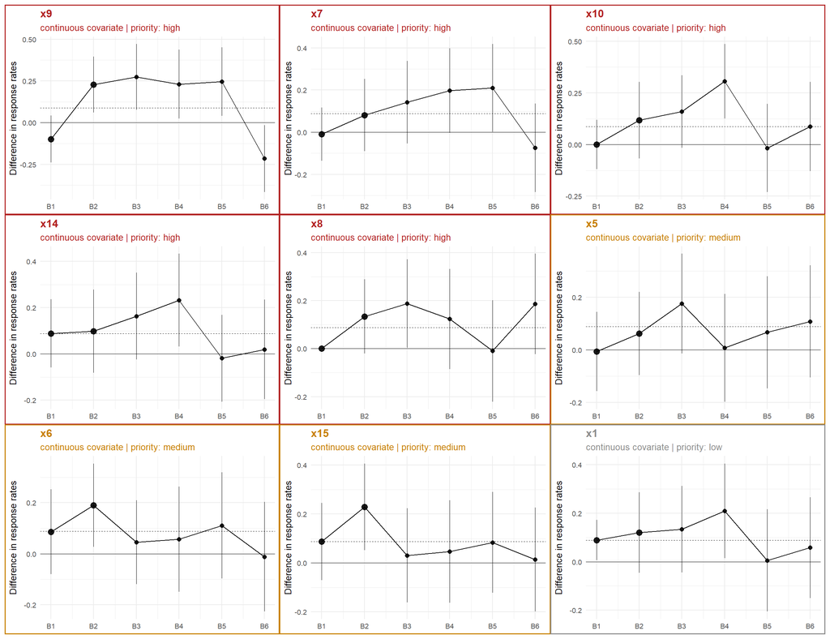

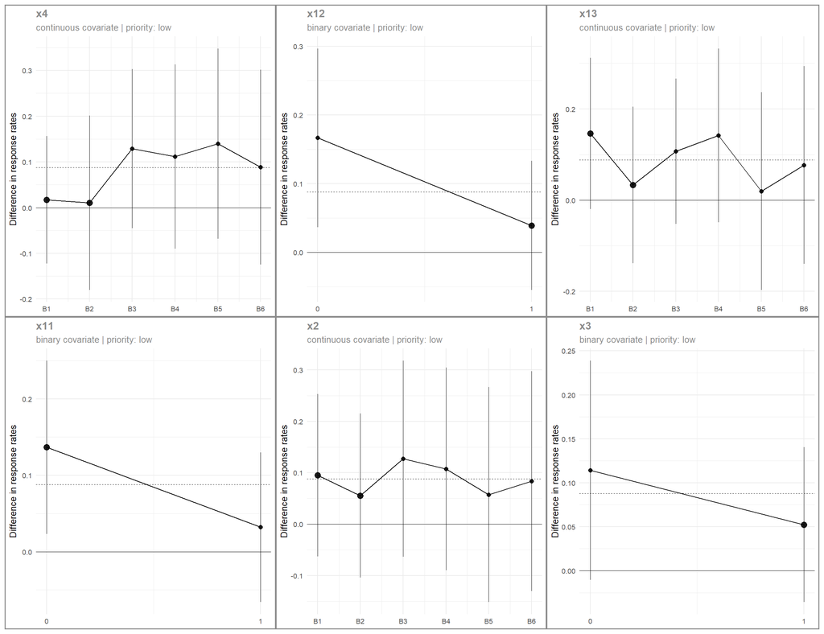

## Dataset 6628

All variables are shown. Numeric prioritisation is used only to order and colour the plots for faster visual review.

| dataset_id | endpoint | n_obs | n_vars | n_bins | overall_effect |
| --- | --- | --- | --- | --- | --- |
| 6628 | binary | 500 | 6 | 6 | 0.028 |

### Dataset priority overview

| n_high | n_medium | n_low | prop_high | prop_medium_or_higher | max_priority_score | mean_priority_score | top_priority_vars | dataset_priority_hint |
| --- | --- | --- | --- | --- | --- | --- | --- | --- |
| 3 | 2 | 1 | 0.5 | 0.833 | 0.995 | 0.675 | x2, x5, x1, x6, x4 | multiple_high_priority_signals |

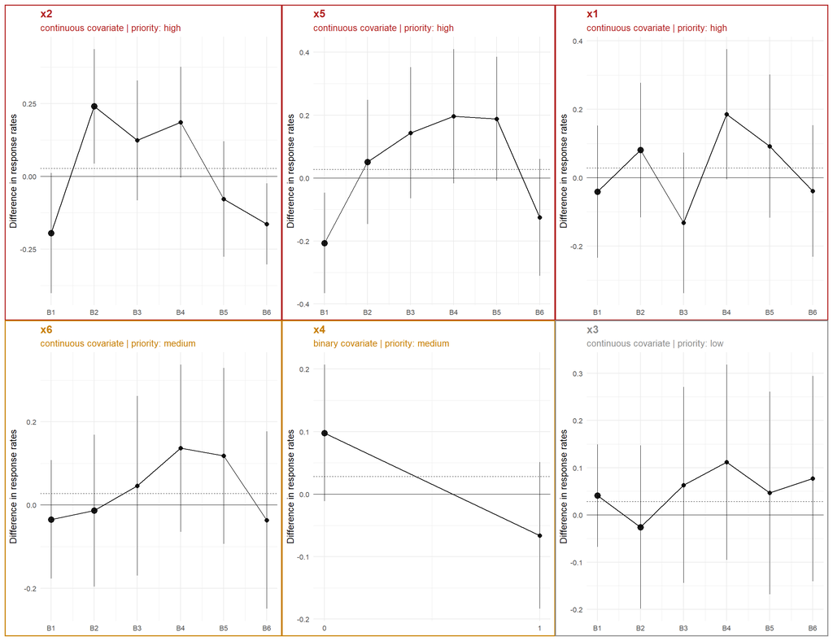

## Dataset 7164

All variables are shown. Numeric prioritisation is used only to order and colour the plots for faster visual review.

| dataset_id | endpoint | n_obs | n_vars | n_bins | overall_effect |
| --- | --- | --- | --- | --- | --- |
| 7164 | binary | 500 | 50 | 6 | 0.348 |